# Reproducible Research: Peer Assessment 1

## Loading and preprocessing the data

###1.Loading and reading the data

```r
if(!file.exists('activity.csv')){
    unzip('activity.zip')
}
Data1 <- read.csv('activity.csv', as.is = TRUE)
```

###2.Process the data into a format suitable for analysis (omit NAs)

```r
Data <- na.omit(Data1)
```

## What is mean total number of steps taken per day?

###1.Calculate the total number of steps taken per day

```r
daily <- group_by(Data, date)
daily_steps <- summarise(daily, total = sum(steps))
daily_steps
```

```
## # A tibble: 53 x 2
##    date       total
##  * <chr>      <int>
##  1 2012-10-02   126
##  2 2012-10-03 11352
##  3 2012-10-04 12116
##  4 2012-10-05 13294
##  5 2012-10-06 15420
##  6 2012-10-07 11015
##  7 2012-10-09 12811
##  8 2012-10-10  9900
##  9 2012-10-11 10304
## 10 2012-10-12 17382
## # … with 43 more rows
```

###2.Make a histogram of the total number of steps taken each day

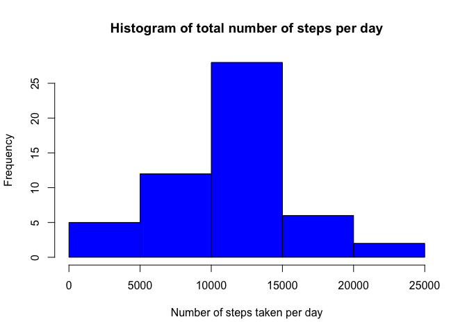

```r
hist(daily_steps$total, main="Histogram of total number of steps per day",
     xlab="Number of steps taken per day", col="blue")
```

###3.Calculate the mean and median of the total number of steps taken per day

```r
meansteps <- mean(daily_steps$total)
mediansteps <- median(daily_steps$total)

summary(daily_steps)
```

```
##      date               total
##  Length:53          Min.   :   41
##  Class :character   1st Qu.: 8841
##  Mode  :character   Median :10765
##                     Mean   :10766
##                     3rd Qu.:13294
##                     Max.   :21194
```

## What is the average daily activity pattern?

###1. Make a time series plot

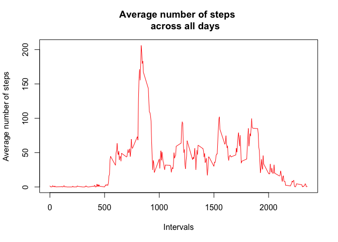

```r
steps_interval <- aggregate(steps ~ interval, Data, mean)

plot(steps_interval$interval, steps_interval$steps, type='l', xlab="Intervals",
     ylab="Average number of steps",  main="Average number of steps
     across all days", col="red")
```

###2.Which 5-minute interval, on average across all the days in the dataset, contains the maximum number of steps?

```r
maximum <- which.max(steps_interval$steps)
maximum1<- steps_interval[maximum, ]$interval
maximum2<- steps_interval[maximum, ]$steps
```

*On average, the maximum number of steps in a 5-minute interval is:206.1698113* The time interval that contains the maximum number of steps is: 835

## Imputing missing values

###1.Calculate and report the total number of missing values in the dataset

```r
missing<-sum(is.na(Data1))
```

- Number of missing values: 2304

```r
for (i in 1:nrow(Data1)) {
    if(is.na(Data1$steps[i])) {
      mis <- steps_interval$steps[which(steps_interval$interval == Data1$interval[i])]
        Data1$steps[i] <- mis
    }
}
```

###3.Create a new dataset that is equal to the original dataset.

```r
steps_new <- aggregate(steps ~ date, Data1, sum)
```

###4.Make a histogram of the total number of steps taken each day.

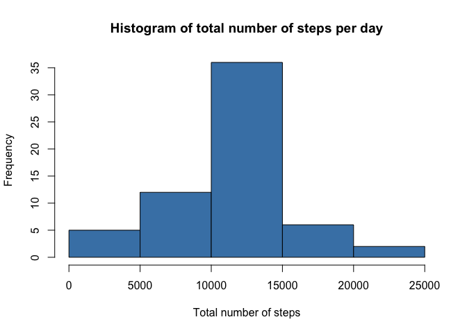

```r
hist(steps_new$steps, xlab="Total number of steps",
main="Histogram of total number of steps per day", col="steelblue")
```

```r
new_mean<-mean(steps_new$steps)
new_median<-median(steps_new$steps)
```

## Are there differences in activity patterns between weekdays and weekends?

###1. Create a new factor variable in the dataset with two levels

```r
Data1['day'] <- weekdays(as.Date(Data1$date))
Data1$day[Data1$day  %in% c('Saturday','Sunday') ] <- "Weekend"
Data1$day[Data1$day != "Weekend"] <- "Weekday"

Data1$day <- as.factor(Data1$day)
stepsnew2 <- aggregate(steps ~ interval+day, Data1, mean)
```

###2.Make a panel plot containing a time series plot

[figure not shown]

```r
finalplot <- ggplot(stepsnew2, aes(interval, steps)) +
  geom_line(stat = "identity", aes(colour = day)) +  labs(x="Intervals", y=expression("Total number of Steps")) + ggtitle("Total of steps per interval by
day of the week") + facet_grid(day ~ .)
finalplot
```